# prelim_EDA_watershed_emma

```r
watershed <- read.csv("../Data/combined_data_clean.csv")
```

I read in the data, it has already been cleaned so I didn’t need to do much.

```r
library(tidyverse)
library(ggplot2)
library(tidymodels)
library(DataExplorer)
```

## R Markdown

```r
watershed %>%
  count(Site) %>%
  arrange(desc(n))
```

```
##          Site   n
## 1        Lime 333
## 2  North Bear 274
## 3         Mud 272
## 4        Blue 269
## 5      Morgan 265
## 6        Bear 252
## 7         ICS 251
## 8         MCJ 250
## 9       Otter 248
## 10       ICLM 134
## 11     ICThom 132
## 12        ICN 114
## 13       MC42 107
## 14        Dry 102
```

[output cut: 29 more lines]

A count of the number of observations for each of the sites in the dataset.

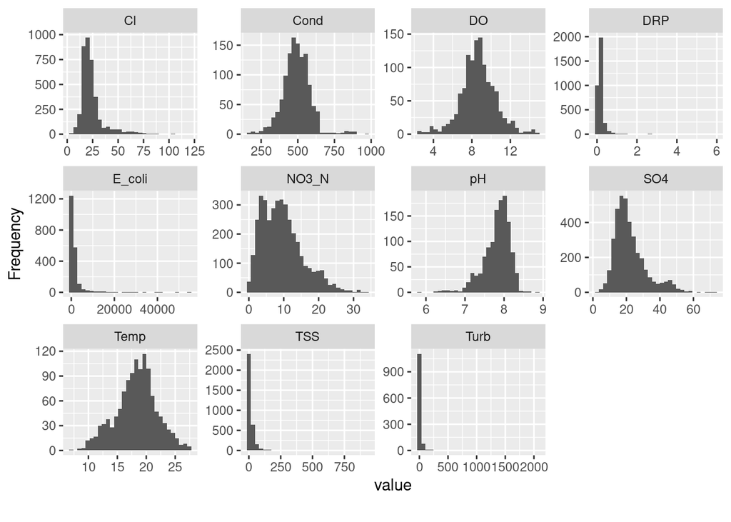

```r
watershed %>%
  select(DO, Temp, pH, Cond, Turb, TSS, DRP, Cl, NO3_N, SO4, E_coli) %>%
  plot_histogram(nrow = 4, ncol = 4)
```

A histogram several different variables of interest, just to get an idea of what the distributions look like. Temperature, conductivity, dissolved oxygen, and pH all have fairly normal distributions. The rest of the variables (SO4, NO3_N, Cl, DRP, TSS, Turb, E_coli) are all right-skewed, some more strongly than others. It’s interesting that variables that are related more to the contents of the water (TSS, Turb, NO3_N, E_coli, etc.) tend to be right-skewed while that variables that are related to the physical/chemical properties of the water (pH, temp, Cond) tend to be normally distributed. DO is weird because it relates to the content of the water (amount of oxygen), but is also related to physical changes in the water (temperature especially).

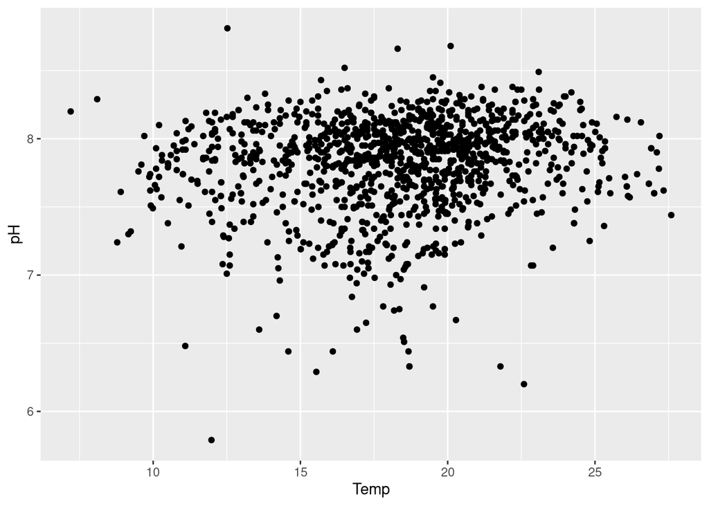

```r
ggplot(watershed, aes(x = Temp, y = pH)) +
         geom_point()
```

Graph of temp vs pH could be vaguely linear but shows no clear correlation.

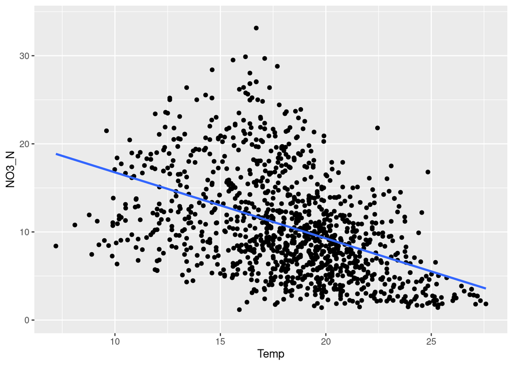

```r
ggplot(watershed, aes(x = Temp, y = NO3_N)) +
  geom_point()+
  geom_smooth(method=lm, se=FALSE)
```

```r
temp_vs_no3_fit <- linear_reg() %>%
  set_engine("lm") %>%
  fit(NO3_N ~ Temp, data = watershed)
  tidy(temp_vs_no3_fit)
```

```
## # A tibble: 2 × 5
##   term        estimate std.error statistic   p.value
##   <chr>          <dbl>     <dbl>     <dbl>     <dbl>
## 1 (Intercept)   24.3      0.783       31.0 1.37e-155
## 2 Temp          -0.749    0.0421     -17.8 3.39e- 63
```

```r
glance(temp_vs_no3_fit)
```

```
## # A tibble: 1 × 12
##   r.squared adj.r.squared sigma statistic  p.value    df logLik   AIC   BIC
##       <dbl>         <dbl> <dbl>     <dbl>    <dbl> <dbl>  <dbl> <dbl> <dbl>
## 1     0.208         0.208  5.19      317. 3.39e-63     1 -3703. 7412. 7428.
## # … with 3 more variables: deviance <dbl>, df.residual <int>, nobs <int>
```

Graph of temp vs. NO3 has a slightly negative, linear relationship (fans out in lower temps and narrows in higher temps), indicating that as temperature increases, NO3 levels decrease. The data could possibly benefit from a transformation.

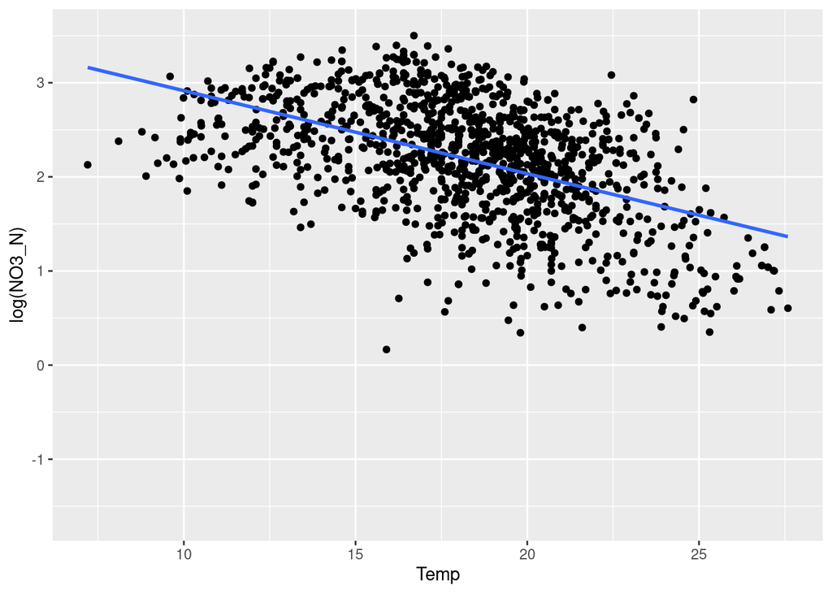

```r
ggplot(watershed, aes(x = Temp, y = log(NO3_N))) +
  geom_point()+
  geom_smooth(method=lm, se=FALSE)
```

The graph of log(NO3_N) vs. temp looks a little better than the untransformed version (there’s less of a cone shape in this graph) but looks like it has a slight curve (concave). The relationship appears stronger and it’s still negative.

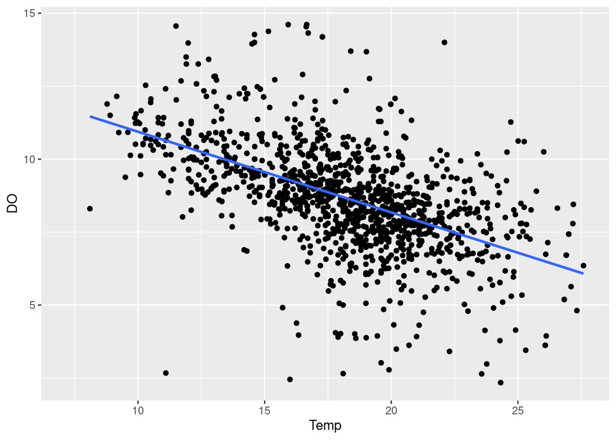

```r
ggplot(watershed, aes(x = Temp, y = DO)) +
         geom_point()+
  geom_smooth(method=lm, se=FALSE)
```

```r
temp_vs_DO_fit <- linear_reg() %>%
  set_engine("lm") %>%
  fit(DO ~ Temp, data = watershed)
  tidy(temp_vs_DO_fit)
```

```
## # A tibble: 2 × 5
##   term        estimate std.error statistic  p.value
##   <chr>          <dbl>     <dbl>     <dbl>    <dbl>
## 1 (Intercept)   13.7      0.235       58.3 0
## 2 Temp          -0.276    0.0126     -21.9 1.50e-89
```

```r
glance(temp_vs_DO_fit)
```

```
## # A tibble: 1 × 12
##   r.squared adj.r.squared sigma statistic  p.value    df logLik   AIC   BIC
##       <dbl>         <dbl> <dbl>     <dbl>    <dbl> <dbl>  <dbl> <dbl> <dbl>
## 1     0.286         0.285  1.55      479. 1.50e-89     1 -2227. 4460. 4476.
## # … with 3 more variables: deviance <dbl>, df.residual <int>, nobs <int>
```

Graph of temp vs. DO (dissolved oxygen) shows a slightly negative, linear relationship. This indicates that as temperature increases, the levels of dissolved oxygen decrease. This is consistent with the packet and with how solubility works (solubility of a gas in liquid decreases as temperature increases). The linear model has an r-squared adj. of ~0.28, indicating that about 28% of the change in DO levels is explained by the change in temperature.

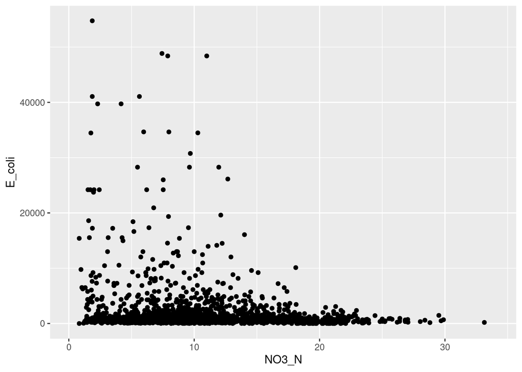

```r
ggplot(watershed, aes(x = NO3_N, y = E_coli)) +
         geom_point()
```

```r
no3_vs_ecoli_fit <- linear_reg() %>%
  set_engine("lm") %>%
  fit(E_coli ~ NO3_N, data = watershed)
  tidy(no3_vs_ecoli_fit)
```

```
## # A tibble: 2 × 5
##   term        estimate std.error statistic  p.value
##   <chr>          <dbl>     <dbl>     <dbl>    <dbl>
## 1 (Intercept)    2870.     199.      14.5  3.47e-45
## 2 NO3_N          -100.      17.6     -5.69 1.44e- 8
```

```r
glance(no3_vs_ecoli_fit)
```

```
## # A tibble: 1 × 12
##   r.squared adj.r.squared sigma statistic    p.value    df  logLik    AIC    BIC
##       <dbl>         <dbl> <dbl>     <dbl>      <dbl> <dbl>   <dbl>  <dbl>  <dbl>
## 1    0.0154        0.0150 4320.      32.4    1.44e-8     1 -20235. 40475. 40492.
## # … with 3 more variables: deviance <dbl>, df.residual <int>, nobs <int>
```

Graph of NO3_N vs E_coli has no clear pattern and a very low r-squared, indicating that NO3 levels aren’t correlated with E.coli levels. I had expected that E.coli levels would increases as NO3 levels increase because nitrates are a source of nurients for algae/bacteria, and because the papers and packet describe how increasing nitrate levels cause algal blooms/eutrophication. It’s possible the data needs to be transformed.

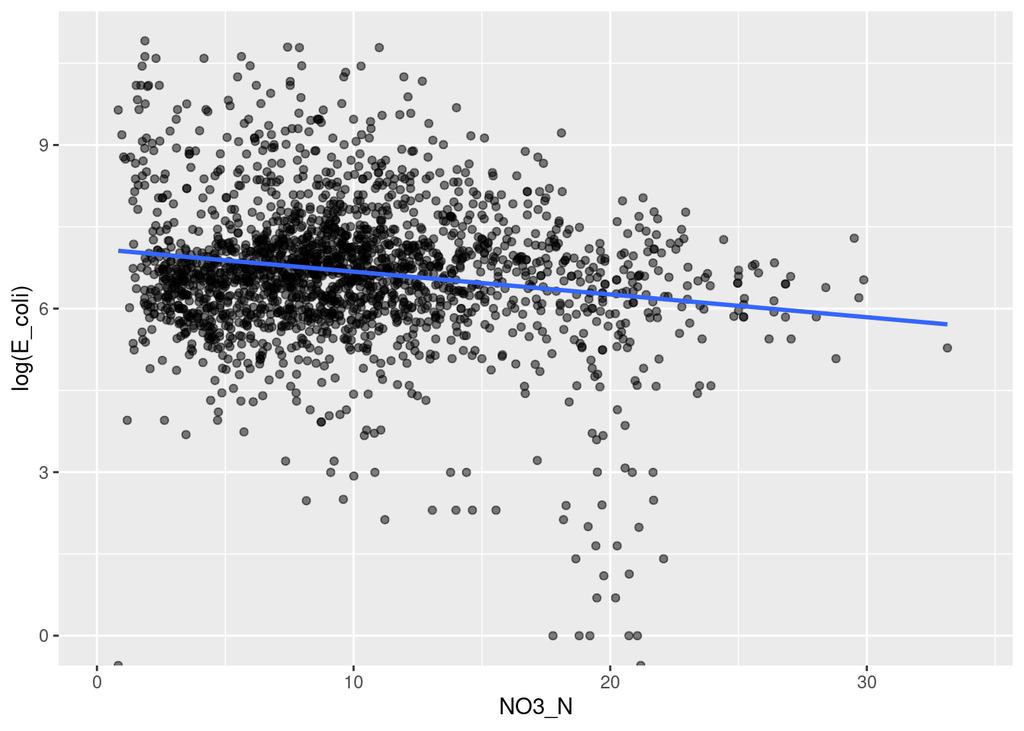

```r
ggplot(watershed, aes(x = NO3_N, y = log(E_coli))) +
         geom_point(alpha = 0.5) +
   geom_smooth(method=lm, se=FALSE)
```

I tried transforming the data and it does look better, but still does not show a strong relationship (also I probably broke some kind of stats rule). The line of best fit shows a negative relationship, which is the opposite of what I would expect.

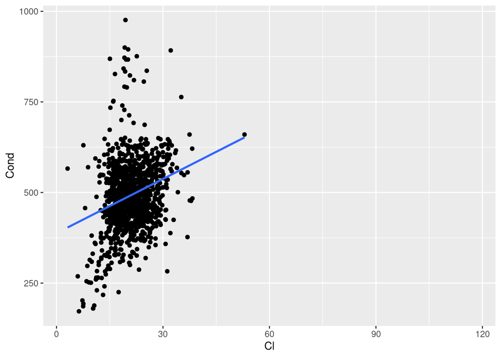

```r
ggplot(watershed, aes(x = Cl, y = Cond)) +
         geom_point()+
  geom_smooth(method=lm, se=FALSE)
```